# Data Pre-Processing Chapter Takeaways

# Get the Book

There is an excellent book called Applied Predictive Modeling and if you are interested in machine learning and statistics, then check it out at the link.

# Intro

- Tree-based models are notably insensitive to the characteristics of the predictor data
- Combinations of predictors can sometimes be more effectie than using the individual values
  - The ratio of two predictors may be more effective than using two independent predictors

# Centering and Scaling

To **center** a predictor variable, the average predictor value is subtracted from all values. Thus, the data has $0$ mean.

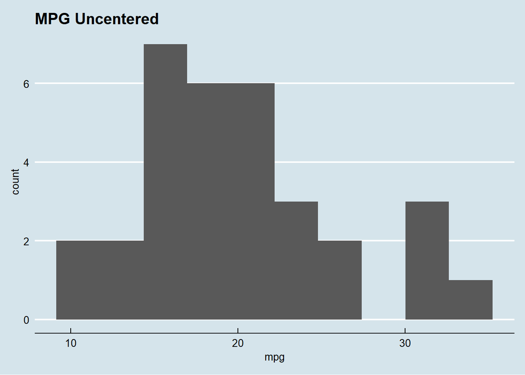

```r
rm(list = ls())
library(ggplot2)
library(ggthemes)

ggplot(mtcars, aes(x = mpg)) +
  geom_histogram(bins = 10) +
  ggtitle("MPG Uncentered") +
  theme_economist()
```

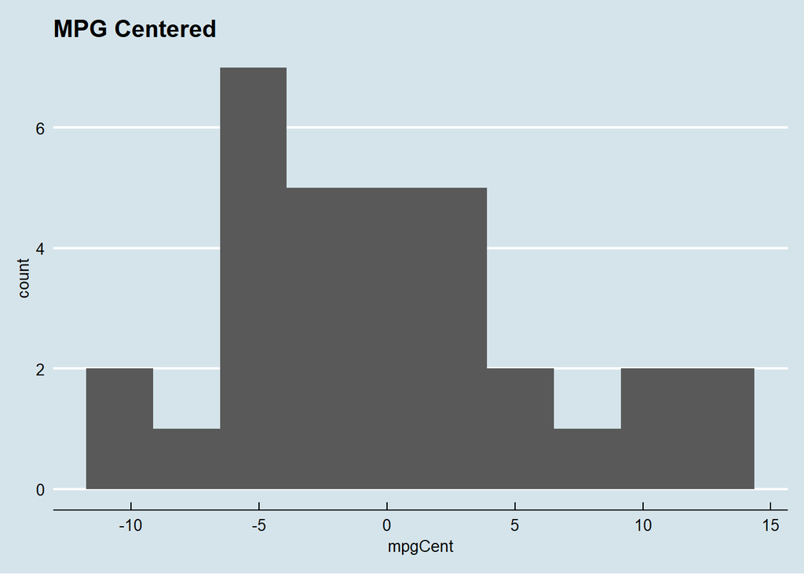

```r
center = function(vector) {
  vector - mean(vector)
}
mpgCent = center(mtcars$mpg)
mpgCent = data.frame( mpgCent = mpgCent)

ggplot(mpgCent, aes(x = mpgCent)) +
  geom_histogram(bins = 10) +
  ggtitle("MPG Centered") +
  theme_economist()
```

To **scale** a variable, the vector is divided by it’s standard deviation. Here, we are coercing the data to have a standard deviation of 1.

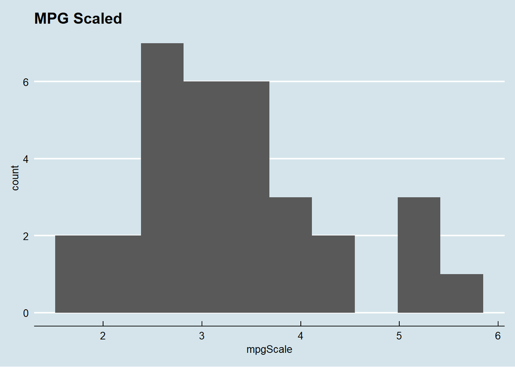

```r
scaled = function(vector) {
  vector/sd(vector)
}
mpgScale = scaled(mtcars$mpg)
mpgScale = data.frame( mpgScale = mpgScale)

ggplot(mpgScale, aes(x = mpgScale)) +
  geom_histogram(bins = 10) +
  ggtitle("MPG Scaled") +
  theme_economist()
```

To *center and scale* data, comnbine the top two techniques.

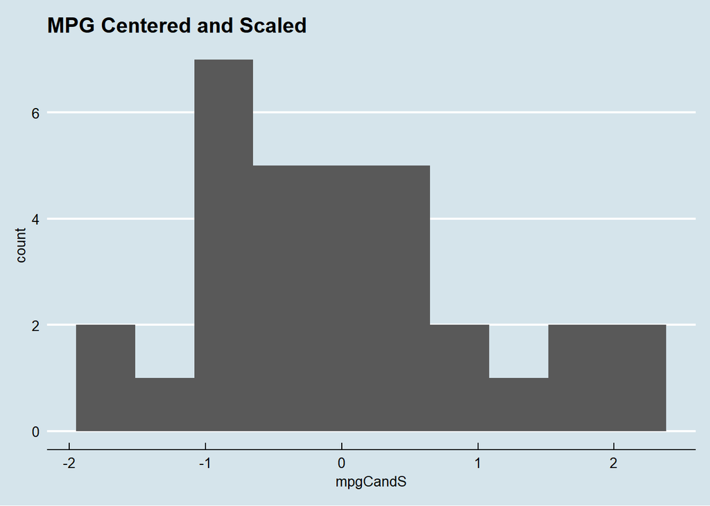

```r
cAndS = function(vector) {
  center(vector)/sd(center(vector))
}

mpgCandS = cAndS(mtcars$mpg)
mpgCandS = data.frame( mpgCandS = mpgCandS)

ggplot(mpgCandS, aes(x = mpgCandS)) +
  geom_histogram(bins = 10) +
  ggtitle("MPG Centered and Scaled") +
  theme_economist()
```

# Resolving Skewness

The formula for skewness is:

$$\text{skew} = \frac{\sum(x_i-\bar{x})^3}{(n-1)v^{3/2}} \\
\text{where}\:\;v = \frac{\sum(x_i-\bar{x})^2}{(n-1)}$$

where $x$ is the predictor variable, $n$ is the number of values, and $\bar{x}$ is the sample mean of the predictor.

Let’s load some data from my website which was taken from a Kaggle competition. You can find the link to the data here.

```r
houses = read.csv("http://fdrennan.net/pages/pages2/datasets/housetrain.csv")
```

Here, we have some skewed data related to selling prices. The distribution makes intutitive sense. However, we can improve the distribution by taking the log of the distribution. Let’s observe.

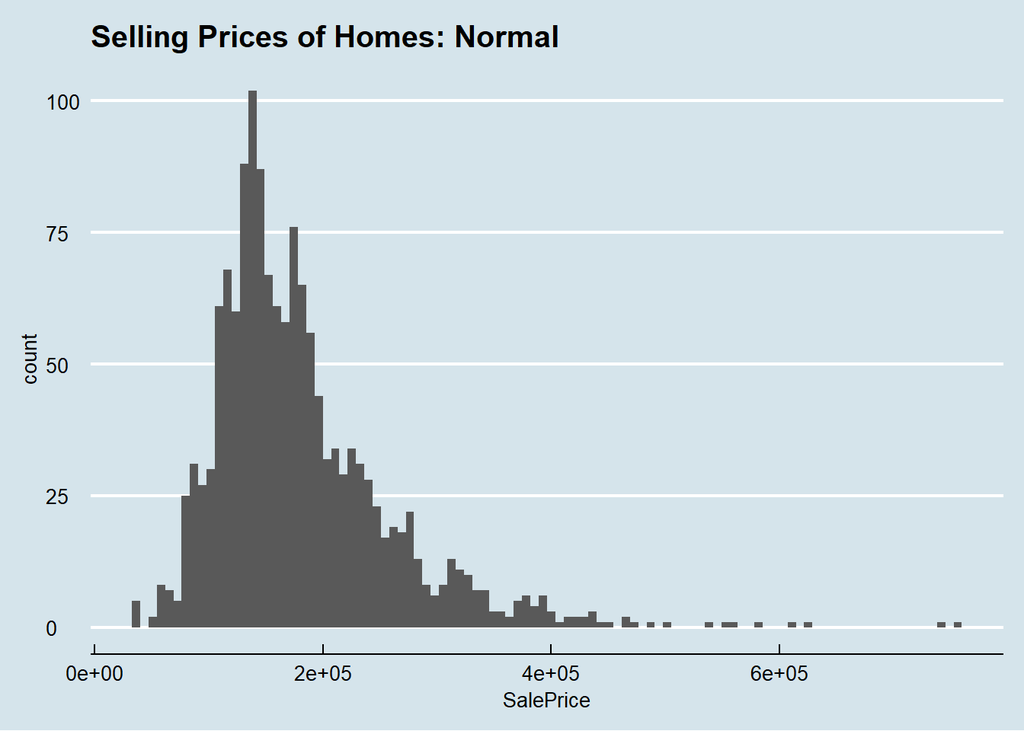

```r
ggplot(houses, aes(x = SalePrice)) +
  geom_histogram(bins = 100) +
  theme_economist() +
  ggtitle("Selling Prices of Homes: Normal")
```

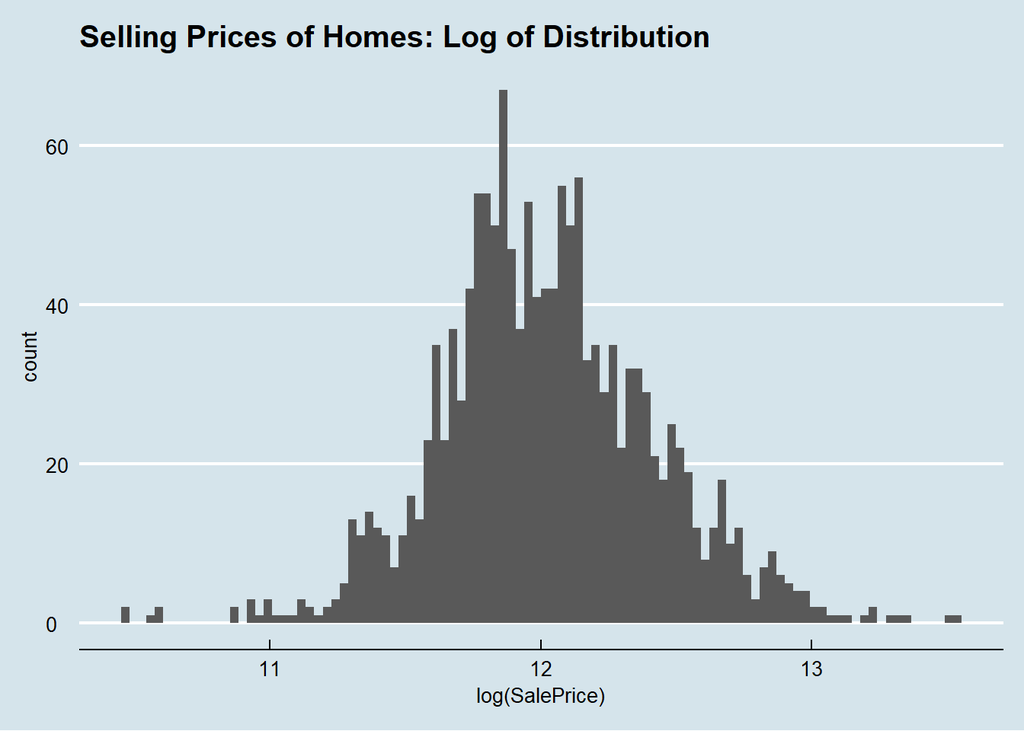

```r
ggplot(houses, aes(x = log(SalePrice))) +
  geom_histogram(bins = 100) +
  theme_economist() +
  ggtitle("Selling Prices of Homes: Log of Distribution")
```

# Box-Cox Transformation

There is a good explanation of the Box-Cox transformation here.

This family of transformations is indexed by a parameter $\lambda$, which will be shown in an example later.

$$f(x) = \left\{
\begin{array}{ll}
\frac{x^{\lambda}-1}{\lambda} & \text{if}\;\; \lambda \neq 0 \\
\text{log}(x) & \text{if}\;\; \lambda = 0
\end{array}
\right.$$

# Outliers

- Tree based models tend to be resistant to missing values.
- If a model is considered to be sensitive to outliers, one data transformation that can minimize the problem is the *spatial sign*.

$$x^*_{ij} = \frac{x_{ij}}{\sqrt{\sum_{j=1}^{P}x^2_{ij}}}$$

Good explanation here from stack overflow. Code edited slightly using the `ICSNP` package.

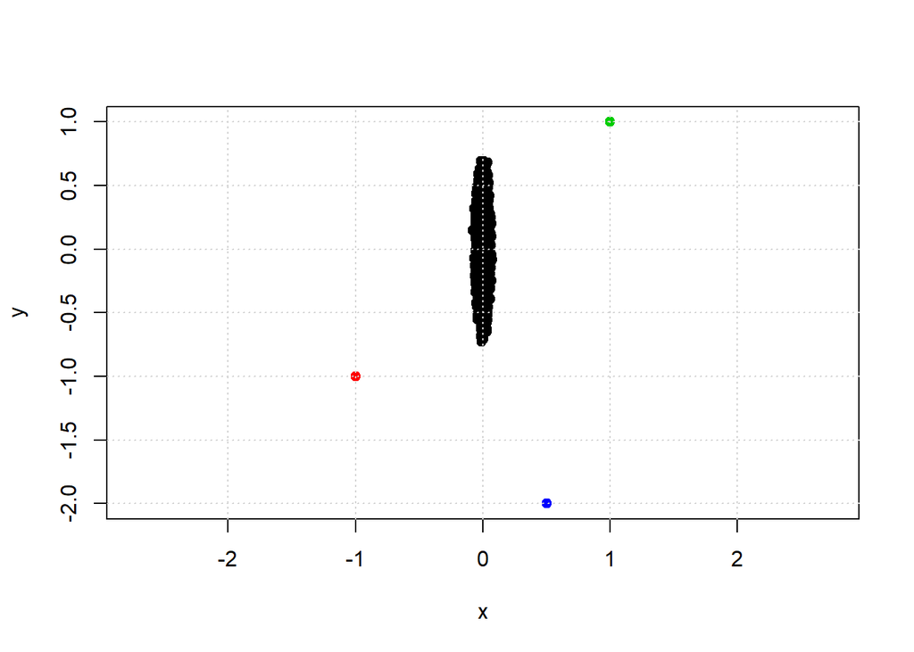

```r
n <- 10000
tmp <- data.frame(x=c(rnorm(n, 0, 0.02), -1, 1, 0.5),
                  y=c(rnorm(n, 0, 0.2), -1, 1, -2))

plot(tmp, asp=1, col=c(rep(1,n), 2, 3, 4), pch=19)
grid()
```

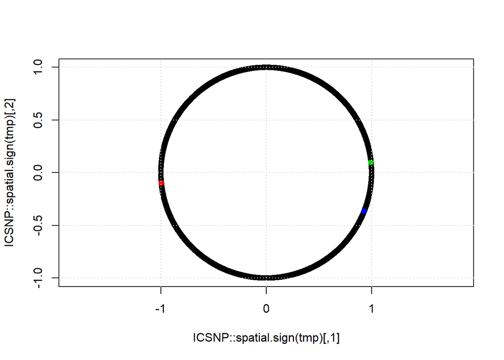

```r
plot(ICSNP::spatial.sign(tmp), asp=1, col=c(rep(1,n), 2, 3, 4), pch=19)
grid()
```

# Data Reduction and Feature Extraction

- PCA is commonly used.
- Generally, new predictors are functions of the original predictors. All the original predictors are needed to create the surrogate variables.
- The primary advantage of PCA, and the reason that it has retained its populatrity as a data reduction method, is that it creates components that are uncorrelated.
- Practitioners must understand the PCA seeks predictor-set variation without regard to any further understanding of the predictors.
- To help PCA avoid summarizing distributional differences and predictor scale information, it is best ot first transform skewed predictors and then center and scale the predictors prior to performing PCA.
- If the predictive relationship between the predictors and the response is not connected to the predictors’ variabliity, then the derived PCs will not provide a suitable relationship with the response. In this case, a *supervised technique*, like PLA will derive componentes while simultaneously considering the corresponding reponse.
- In an automated model building process, the optimial number of components can be determined by cross-validation.
- Skewed predictors can have an impact on PCA. Consider doing Box-Cox first and then after the transformations, center and scale and do PCA.

# Missing Data

- Missing values actually may represent something and should be encoded with a variable indivator.
- Missing values may represent data in the form of individuals who couldn’t finish the study related to events within the study. For example, someone in a medical study might have left because the medication made he or she worse off. Obviously, this is data that you would not want to miss.
- A value may be missing because of a cutoff. Think an assay where there is a minimal detectable limit. In this case, use a random variable between 0 and the cutoff limit.
- A few predictive models, especially tree-based techniques, can specifically account for missing dat.
- For predictive models we are concerned about accuracy of the predictions rather than making valid inferences.
- Prior to model trianing or the prediction of new samples, missing values are filled in using imputation. Note that this extra layer of models adds uncertainty.
- One popular technique for imputation is a K-nearest neightbor model.

```r
# If you don't have the impute package, run the code below
## try http:// if https:// URLs are not supported
# source("https://bioconductor.org/biocLite.R")
# biocLite("impute")


mtc = mtcars
mtc[sample(1:nrow(mtcars), replace = FALSE, size = 4), sample(1:ncol(mtcars), replace = FALSE, size = 4)] = NA
mtc
```

```
##                      mpg cyl  disp  hp drat    wt  qsec vs am gear carb
## Mazda RX4           21.0  NA 160.0 110 3.90    NA 16.46  0  1   NA   NA
## Mazda RX4 Wag       21.0   6 160.0 110 3.90 2.875 17.02  0  1    4    4
## Datsun 710          22.8  NA 108.0  93 3.85    NA 18.61  1  1   NA   NA
## Hornet 4 Drive      21.4   6 258.0 110 3.08 3.215 19.44  1  0    3    1
## Hornet Sportabout   18.7   8 360.0 175 3.15 3.440 17.02  0  0    3    2
## Valiant             18.1   6 225.0 105 2.76 3.460 20.22  1  0    3    1
## Duster 360          14.3   8 360.0 245 3.21 3.570 15.84  0  0    3    4
## Merc 240D           24.4  NA 146.7  62 3.69    NA 20.00  1  0   NA   NA
## Merc 230            22.8   4 140.8  95 3.92 3.150 22.90  1  0    4    2
## Merc 280            19.2   6 167.6 123 3.92 3.440 18.30  1  0    4    4
## Merc 280C           17.8   6 167.6 123 3.92 3.440 18.90  1  0    4    4
## Merc 450SE          16.4   8 275.8 180 3.07 4.070 17.40  0  0    3    3
## Merc 450SL          17.3   8 275.8 180 3.07 3.730 17.60  0  0    3    3
## Merc 450SLC         15.2   8 275.8 180 3.07 3.780 18.00  0  0    3    3
## Cadillac Fleetwood  10.4   8 472.0 205 2.93 5.250 17.98  0  0    3    4
## Lincoln Continental 10.4   8 460.0 215 3.00 5.424 17.82  0  0    3    4
## Chrysler Imperial   14.7   8 440.0 230 3.23 5.345 17.42  0  0    3    4
## Fiat 128            32.4   4  78.7  66 4.08 2.200 19.47  1  1    4    1
## Honda Civic         30.4   4  75.7  52 4.93 1.615 18.52  1  1    4    2
## Toyota Corolla      33.9  NA  71.1  65 4.22    NA 19.90  1  1   NA   NA
## Toyota Corona       21.5   4 120.1  97 3.70 2.465 20.01  1  0    3    1
## Dodge Challenger    15.5   8 318.0 150 2.76 3.520 16.87  0  0    3    2
## AMC Javelin         15.2   8 304.0 150 3.15 3.435 17.30  0  0    3    2
## Camaro Z28          13.3   8 350.0 245 3.73 3.840 15.41  0  0    3    4
## Pontiac Firebird    19.2   8 400.0 175 3.08 3.845 17.05  0  0    3    2
## Fiat X1-9           27.3   4  79.0  66 4.08 1.935 18.90  1  1    4    1
## Porsche 914-2       26.0   4 120.3  91 4.43 2.140 16.70  0  1    5    2
## Lotus Europa        30.4   4  95.1 113 3.77 1.513 16.90  1  1    5    2
## Ford Pantera L      15.8   8 351.0 264 4.22 3.170 14.50  0  1    5    4
## Ferrari Dino        19.7   6 145.0 175 3.62 2.770 15.50  0  1    5    6
## Maserati Bora       15.0   8 301.0 335 3.54 3.570 14.60  0  1    5    8
## Volvo 142E          21.4   4 121.0 109 4.11 2.780 18.60  1  1    4    2
```

```r
mtc = impute::impute.knn(as.matrix(mtc))
mtc = mtc$data
mtcars
```

```
##                      mpg cyl  disp  hp drat    wt  qsec vs am gear carb
## Mazda RX4           21.0   6 160.0 110 3.90 2.620 16.46  0  1    4    4
## Mazda RX4 Wag       21.0   6 160.0 110 3.90 2.875 17.02  0  1    4    4
## Datsun 710          22.8   4 108.0  93 3.85 2.320 18.61  1  1    4    1
## Hornet 4 Drive      21.4   6 258.0 110 3.08 3.215 19.44  1  0    3    1
## Hornet Sportabout   18.7   8 360.0 175 3.15 3.440 17.02  0  0    3    2
## Valiant             18.1   6 225.0 105 2.76 3.460 20.22  1  0    3    1
## Duster 360          14.3   8 360.0 245 3.21 3.570 15.84  0  0    3    4
## Merc 240D           24.4   4 146.7  62 3.69 3.190 20.00  1  0    4    2
## Merc 230            22.8   4 140.8  95 3.92 3.150 22.90  1  0    4    2
## Merc 280            19.2   6 167.6 123 3.92 3.440 18.30  1  0    4    4
## Merc 280C           17.8   6 167.6 123 3.92 3.440 18.90  1  0    4    4
## Merc 450SE          16.4   8 275.8 180 3.07 4.070 17.40  0  0    3    3
## Merc 450SL          17.3   8 275.8 180 3.07 3.730 17.60  0  0    3    3
## Merc 450SLC         15.2   8 275.8 180 3.07 3.780 18.00  0  0    3    3
## Cadillac Fleetwood  10.4   8 472.0 205 2.93 5.250 17.98  0  0    3    4
## Lincoln Continental 10.4   8 460.0 215 3.00 5.424 17.82  0  0    3    4
## Chrysler Imperial   14.7   8 440.0 230 3.23 5.345 17.42  0  0    3    4
## Fiat 128            32.4   4  78.7  66 4.08 2.200 19.47  1  1    4    1
## Honda Civic         30.4   4  75.7  52 4.93 1.615 18.52  1  1    4    2
## Toyota Corolla      33.9   4  71.1  65 4.22 1.835 19.90  1  1    4    1
## Toyota Corona       21.5   4 120.1  97 3.70 2.465 20.01  1  0    3    1
## Dodge Challenger    15.5   8 318.0 150 2.76 3.520 16.87  0  0    3    2
## AMC Javelin         15.2   8 304.0 150 3.15 3.435 17.30  0  0    3    2
## Camaro Z28          13.3   8 350.0 245 3.73 3.840 15.41  0  0    3    4
## Pontiac Firebird    19.2   8 400.0 175 3.08 3.845 17.05  0  0    3    2
## Fiat X1-9           27.3   4  79.0  66 4.08 1.935 18.90  1  1    4    1
## Porsche 914-2       26.0   4 120.3  91 4.43 2.140 16.70  0  1    5    2
## Lotus Europa        30.4   4  95.1 113 3.77 1.513 16.90  1  1    5    2
## Ford Pantera L      15.8   8 351.0 264 4.22 3.170 14.50  0  1    5    4
## Ferrari Dino        19.7   6 145.0 175 3.62 2.770 15.50  0  1    5    6
## Maserati Bora       15.0   8 301.0 335 3.54 3.570 14.60  0  1    5    8
## Volvo 142E          21.4   4 121.0 109 4.11 2.780 18.60  1  1    4    2
```

```r
mtc-mtcars
```

```
##                     mpg   cyl disp hp drat        wt qsec vs am   gear
## Mazda RX4             0 -1.00    0  0    0  0.348750    0  0  0 -0.125
## Mazda RX4 Wag         0  0.00    0  0    0  0.000000    0  0  0  0.000
## Datsun 710            0  0.00    0  0    0 -0.095250    0  0  0  0.125
## Hornet 4 Drive        0  0.00    0  0    0  0.000000    0  0  0  0.000
## Hornet Sportabout     0  0.00    0  0    0  0.000000    0  0  0  0.000
## Valiant               0  0.00    0  0    0  0.000000    0  0  0  0.000
## Duster 360            0  0.00    0  0    0  0.000000    0  0  0  0.000
## Merc 240D             0  0.75    0  0    0 -0.411875    0  0  0  0.000
## Merc 230              0  0.00    0  0    0  0.000000    0  0  0  0.000
## Merc 280              0  0.00    0  0    0  0.000000    0  0  0  0.000
## Merc 280C             0  0.00    0  0    0  0.000000    0  0  0  0.000
## Merc 450SE            0  0.00    0  0    0  0.000000    0  0  0  0.000
## Merc 450SL            0  0.00    0  0    0  0.000000    0  0  0  0.000
## Merc 450SLC           0  0.00    0  0    0  0.000000    0  0  0  0.000
## Cadillac Fleetwood    0  0.00    0  0    0  0.000000    0  0  0  0.000
## Lincoln Continental   0  0.00    0  0    0  0.000000    0  0  0  0.000
## Chrysler Imperial     0  0.00    0  0    0  0.000000    0  0  0  0.000
## Fiat 128              0  0.00    0  0    0  0.000000    0  0  0  0.000
## Honda Civic           0  0.00    0  0    0  0.000000    0  0  0  0.000
## Toyota Corolla        0  0.00    0  0    0  0.389750    0  0  0  0.125
## Toyota Corona         0  0.00    0  0    0  0.000000    0  0  0  0.000
## Dodge Challenger      0  0.00    0  0    0  0.000000    0  0  0  0.000
## AMC Javelin           0  0.00    0  0    0  0.000000    0  0  0  0.000
## Camaro Z28            0  0.00    0  0    0  0.000000    0  0  0  0.000
## Pontiac Firebird      0  0.00    0  0    0  0.000000    0  0  0  0.000
## Fiat X1-9             0  0.00    0  0    0  0.000000    0  0  0  0.000
## Porsche 914-2         0  0.00    0  0    0  0.000000    0  0  0  0.000
## Lotus Europa          0  0.00    0  0    0  0.000000    0  0  0  0.000
## Ford Pantera L        0  0.00    0  0    0  0.000000    0  0  0  0.000
## Ferrari Dino          0  0.00    0  0    0  0.000000    0  0  0  0.000
## Maserati Bora         0  0.00    0  0    0  0.000000    0  0  0  0.000
## Volvo 142E            0  0.00    0  0    0  0.000000    0  0  0  0.000
##                       carb
## Mazda RX4           -1.500
## Mazda RX4 Wag        0.000
## Datsun 710           0.625
## Hornet 4 Drive       0.000
## Hornet Sportabout    0.000
## Valiant              0.000
```

[output cut: 11 more lines]

```
## Fiat 128             0.000
## Honda Civic          0.000
## Toyota Corolla       0.625
## Toyota Corona        0.000
## Dodge Challenger     0.000
## AMC Javelin          0.000
## Camaro Z28           0.000
## Pontiac Firebird     0.000
## Fiat X1-9            0.000
## Porsche 914-2        0.000
## Lotus Europa         0.000
## Ford Pantera L       0.000
## Ferrari Dino         0.000
## Maserati Bora        0.000
## Volvo 142E           0.000
```

# Between-Predictor Correlations

Multicollinearity, get rid of it. Read here.

- Multicollinearity is when you have strong relationships between multiple predictors.
- There are good reasons to avoid dat with highly correlated predictors. First, redundant predictors frequently add more complexity to the model than information they provide to the model.
- Using highly correlated predictors in techniques like linear regression can result in highly unstable models.

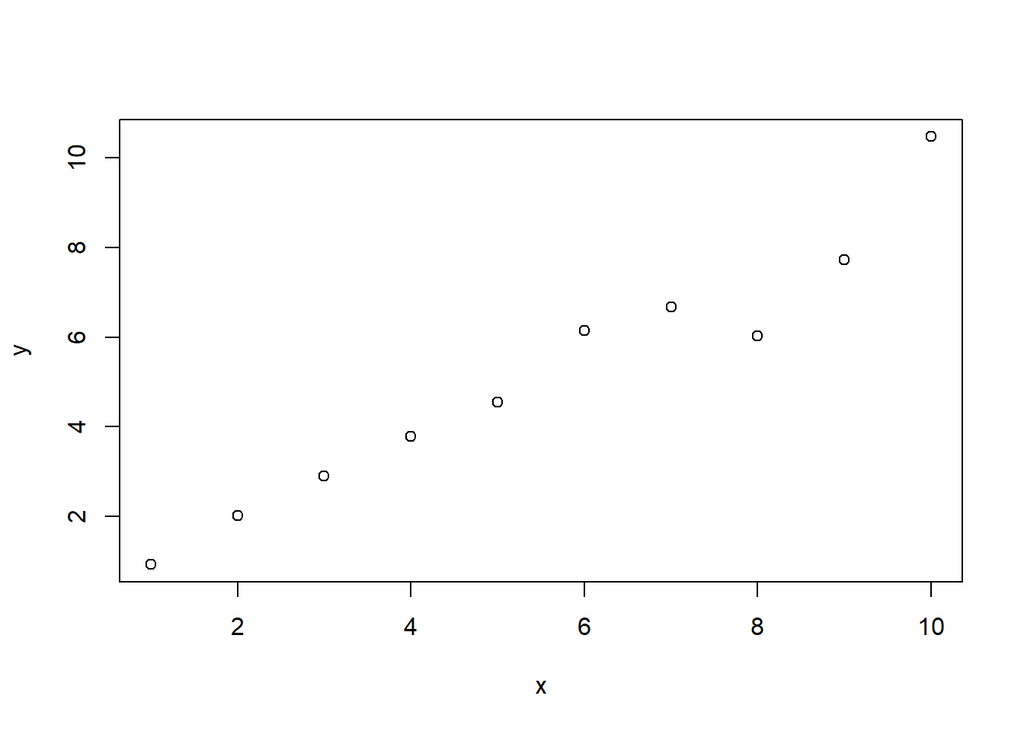

```r
x = 1:10
y = x*(1+rnorm(n = 10, mean = 0, sd = .1))
plot(x,y)
```

```r
cor(x, y)
```

```
## [1] 0.9714641
```

`x` and `y` are clearly related. Collinear predictors can impact the variance of parameter estimates in a model, so a statistic called the variance inflation factor (VIF) can be sued to identify predictors that are impacted.

Another approach is to remove predictors below a certain threshold. The idea is to remove the predictors that have the most correlated relationships. Ths means that we want to eliminate the minimum number of predictors to achieve all pairwise correlations, say, less than 0.75. The code to do this will be shown below.

# Adding Predictors

Sometimes it is better to split factors into binary vectors. For example, a column of male and female predictors may be better suited as a binary vector indicated $1$ for male and $0$ for female. Suppose there are three factors, `cat`, `dog`, and `rabbit`. The vector could be split into two vectors. One binary indicating cat, and another for dog. The Rabbit is implicit in the 0 values missing from `cat` and `dog`.

# Binning Predictors

Don’t do it. For example, people with a heart rate below 80, between 80 and 100, and greater than 100 as binary vectors.

# Computing

Ok, let’s dig into some cool functions.

Check out the package `AppliedPredictiveModeling`’s documentation here

```r
train = read.csv("http://fdrennan.net/pages/pages2/datasets/housetrain.csv")

return_numeric = function(dataset) {
  # Splitting data into numeric columns.
  #################################################

  classes = sapply(dataset, class)

  numericCols = names(classes[classes != "factor"])
  originalNumeric = dataset[numericCols]
  originalNumeric
}

train = return_numeric(train)

# Removing a date column and id columns
response = train[39]
train=train[-c(1:2, 38,39)]
```

To determine which type of transformation should be used, the `MASS` package contains the `boxcox` function. The function estimates $\lambda$ but does not create the transformed variables. A `caret` function, `BoxCoxTrans` can find the appropriate transformation and apply them to the new data. The data below GrLivArea is the above grade (ground) living area square feet for some homes.

```r
library(e1071)
skewness(train$GrLivArea)
```

```
## [1] 1.363754
```

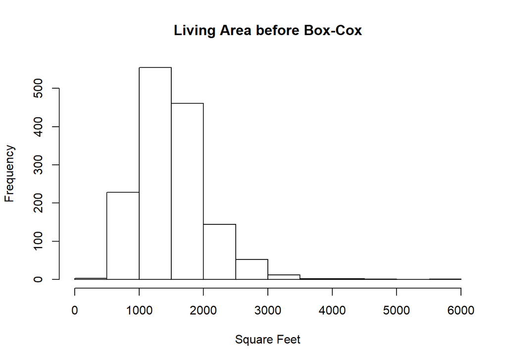

```r
library(caret)
hist(train$GrLivArea, main = "Living Area before Box-Cox", xlab = "Square Feet")
```

```r
BoxCoxTrans = BoxCoxTrans(train$GrLivArea)
BoxCoxTrans
```

```
## Box-Cox Transformation
##
## 1460 data points used to estimate Lambda
##
## Input data summary:
##    Min. 1st Qu.  Median    Mean 3rd Qu.    Max.
##     334    1130    1464    1515    1777    5642
##
## Largest/Smallest: 16.9
## Sample Skewness: 1.36
##
## Estimated Lambda: 0
## With fudge factor, Lambda = 0 will be used for transformations
```

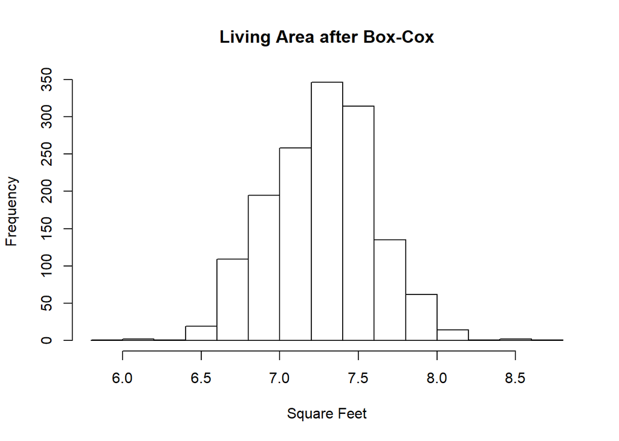

```r
predictedTransform = predict(BoxCoxTrans, train$GrLivArea)
hist(predictedTransform, main = "Living Area after Box-Cox", xlab = "Square Feet")
```

```r
# If you don't have the impute package, run the code below
## try http:// if https:// URLs are not supported
# source("https://bioconductor.org/biocLite.R")
# biocLite("impute")

library(impute)

trainImpute = impute.knn(as.matrix(train))
trainImpute = trainImpute$data
pcaObject = prcomp(trainImpute,
                   center = TRUE,
                   scale = TRUE)

# Calculates the cumulative percentage of variance which each
# component accounts for.

percentVariance = pcaObject$sd^2/sum(pcaObject$sd^2)*100
percentVariance[1:3]
```

```
## [1] 20.573479  9.167009  7.526543
```

```r
head(pcaObject$rotation[,1:3])
```

```
##                     PC1          PC2        PC3
## MSSubClass  -0.01766422 -0.159039115  0.2354992
## LotFrontage  0.16905114 -0.007522036 -0.3250412
## LotArea      0.10956356  0.024295246 -0.2921168
## OverallQual  0.29904888  0.019075550  0.1119183
## OverallCond -0.08195353 -0.062271172 -0.1264636
## YearBuilt    0.23611753  0.202566257  0.3142494
```

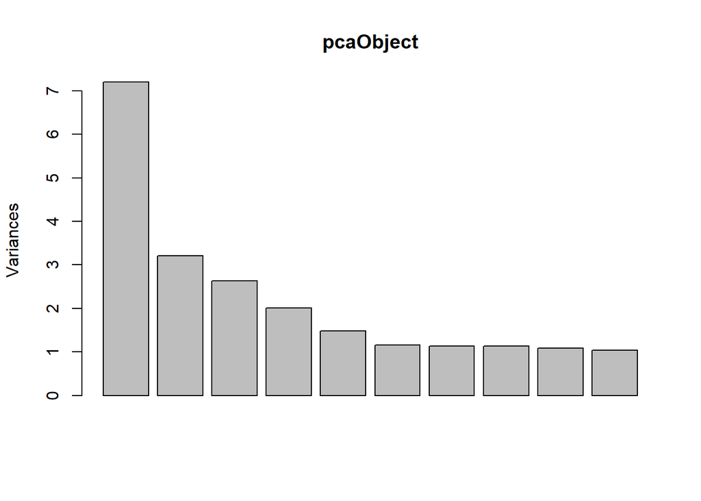

```r
plot(pcaObject)
```

To Box-Cox transform, center, and scale the dat, then excecute PCA for signal extraction, the syntax would be:

```r
trans = preProcess(trainImpute,
                   method = c("BoxCox", "center", "scale", "pca"))

trans
```

```
## Created from 1460 samples and 35 variables
##
## Pre-processing:
##   - Box-Cox transformation (12)
##   - centered (35)
##   - ignored (0)
##   - principal component signal extraction (35)
##   - scaled (35)
##
## Lambda estimates for Box-Cox transformation:
##    Min. 1st Qu.  Median    Mean 3rd Qu.    Max.
##   -0.20    0.00    0.45    0.70    1.10    2.00
##
## PCA needed 25 components to capture 95 percent of the variance
```

```r
transformed = predict(trans, trainImpute)

# These values are different than the previous PCA since
# they were transformed prior to PCA.
head(transformed[, 1:5])
```

```
##             PC1        PC2        PC3        PC4         PC5
## [1,]  1.4986629 -0.7017390  1.9159988 -1.6037723  0.56289366
## [2,]  0.1252425  1.3184475 -1.2878212 -0.2571711 -1.74855545
## [3,]  1.7761410 -0.5573018  1.5102730 -1.1229103 -0.01759218
## [4,] -0.2266415 -1.1018008 -0.7338679 -0.5343238  0.76443917
## [5,]  4.5037412 -1.1860622  0.5367803 -1.2743885  0.05603765
## [6,] -0.5485468  1.5909842  1.0536544 -1.1356254 -1.12297747
```

Without pca

```r
trans = preProcess(trainImpute,
                   method = c("BoxCox", "center", "scale"))

trans
```

```
## Created from 1460 samples and 35 variables
##
## Pre-processing:
##   - Box-Cox transformation (12)
##   - centered (35)
##   - ignored (0)
##   - scaled (35)
##
## Lambda estimates for Box-Cox transformation:
##    Min. 1st Qu.  Median    Mean 3rd Qu.    Max.
##   -0.20    0.00    0.45    0.70    1.10    2.00
```

```r
transformed = predict(trans, trainImpute)

# These values are different than the previous PCA since
# they were transformed prior to PCA.
head(transformed[, 1:5])
```

```
##      MSSubClass LotFrontage    LotArea OverallQual OverallCond
## [1,]  0.4303686 -0.18088564 -0.1331854  0.65125610  -0.4784436
## [2,] -1.1285958  0.46303176  0.1134030 -0.07181151   2.0201189
## [3,]  0.4303686 -0.04658977  0.4199169  0.65125610  -0.4784436
## [4,]  0.6491131 -0.41179499  0.1033112  0.65125610  -0.4784436
## [5,]  0.4303686  0.62428557  0.8781083  1.37432370  -0.4784436
## [6,]  0.1716487  0.66399541  0.8583569 -0.79487911  -0.4784436
```

```r
transformed = as.data.frame(transformed)
```

To filter for near-zero variance predictors, the `caret` package function `nearZeroVar` will return the column numbers of any predictors that fulfill the conditions for removal

```r
# A vector of integers to
# is returned by the function nearZeroVar
transformed = transformed[-nearZeroVar(transformed)]
```

To visually examine the correlation structure of the data, use `corrplot`. The `hclust` paramter clusters variables with high correlations with one another.

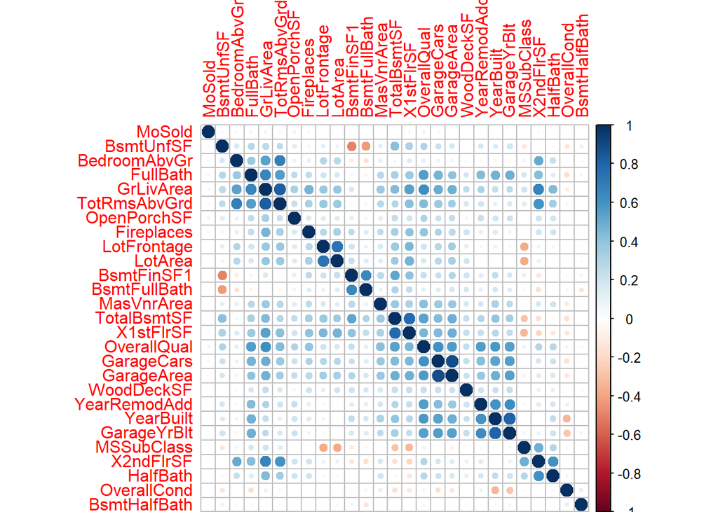

```r
correlations = cor(transformed)
library(corrplot)
corrplot(correlations, order = "hclust")
```

To filter based on correlations, the `fundCorrelation` function return column numbers denoting predictors that are recommened for deletion. That is, they are columns that are already explained by others. It helps remove multicollinearity from the data.

```r
highCorr = findCorrelation(correlations, cutoff = .75)
head(highCorr)
```

```
## [1] 14 12 23  6
```

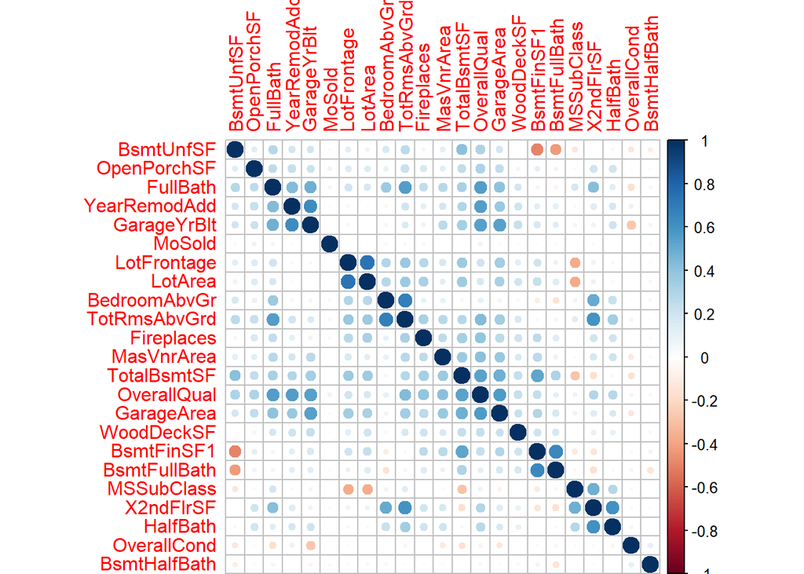

```r
filteredTransformed = transformed[, -highCorr]

correlationFiltered = cor(filteredTransformed)
corrplot(correlationFiltered, order = "hclust")
```

Creating dummy variables

```r
simpleMod = dummyVars(~ Sepal.Length + Species,
                      data = iris,
                      levelsOnly = TRUE)

head(predict(simpleMod, iris))
```

```
##   Sepal.Length setosa versicolor virginica
## 1          5.1      1          0         0
## 2          4.9      1          0         0
## 3          4.7      1          0         0
## 4          4.6      1          0         0
## 5          5.0      1          0         0
## 6          5.4      1          0         0
```

```r
head(class2ind(iris$Species))
```

```
##   setosa versicolor virginica
## 1      1          0         0
## 2      1          0         0
## 3      1          0         0
## 4      1          0         0
## 5      1          0         0
## 6      1          0         0
```

# Exercises

## 3.1

The data can be accessed via:

```r
library(mlbench)
data(Glass)
str(Glass)
```

```
## 'data.frame':    214 obs. of  10 variables:
##  $ RI  : num  1.52 1.52 1.52 1.52 1.52 ...
##  $ Na  : num  13.6 13.9 13.5 13.2 13.3 ...
##  $ Mg  : num  4.49 3.6 3.55 3.69 3.62 3.61 3.6 3.61 3.58 3.6 ...
##  $ Al  : num  1.1 1.36 1.54 1.29 1.24 1.62 1.14 1.05 1.37 1.36 ...
##  $ Si  : num  71.8 72.7 73 72.6 73.1 ...
##  $ K   : num  0.06 0.48 0.39 0.57 0.55 0.64 0.58 0.57 0.56 0.57 ...
##  $ Ca  : num  8.75 7.83 7.78 8.22 8.07 8.07 8.17 8.24 8.3 8.4 ...
##  $ Ba  : num  0 0 0 0 0 0 0 0 0 0 ...
##  $ Fe  : num  0 0 0 0 0 0.26 0 0 0 0.11 ...
##  $ Type: Factor w/ 6 levels "1","2","3","5",..: 1 1 1 1 1 1 1 1 1 1 ...
```

- Using visualizations, explore the predictor variables to understand their distributions as well as the relationships between the predictors.

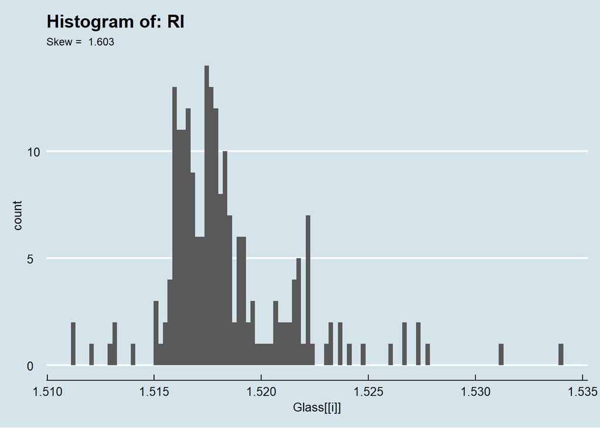

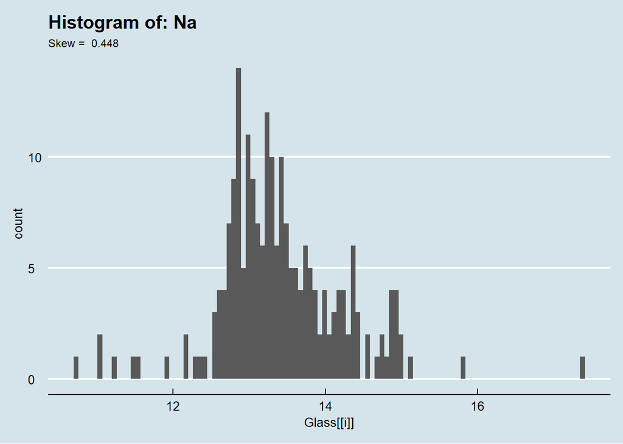

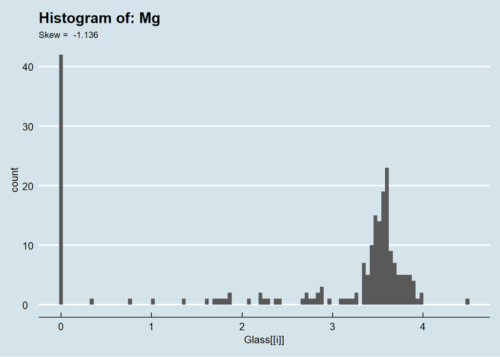

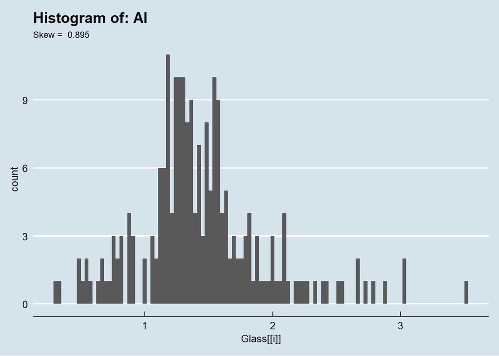

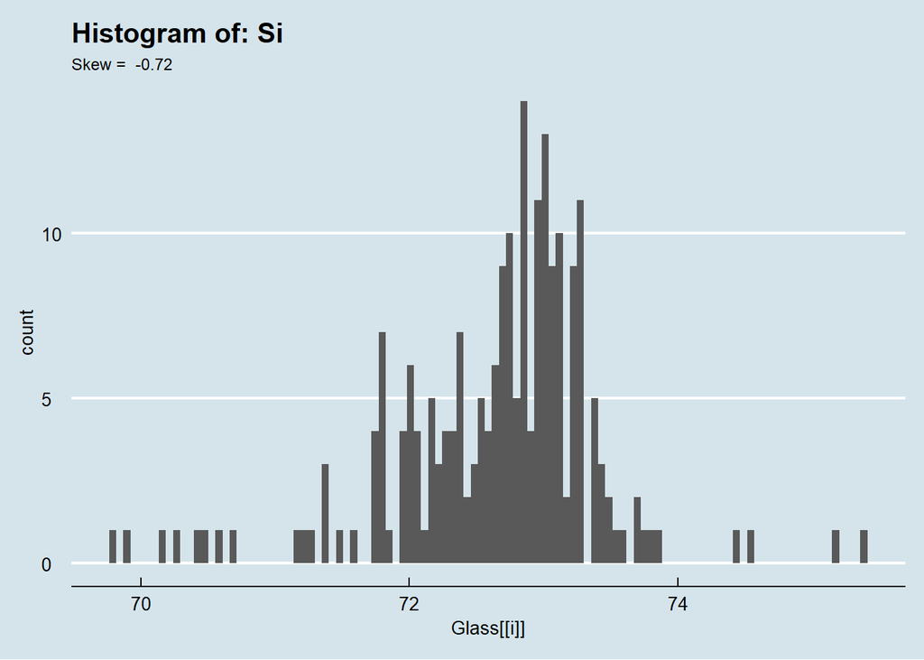

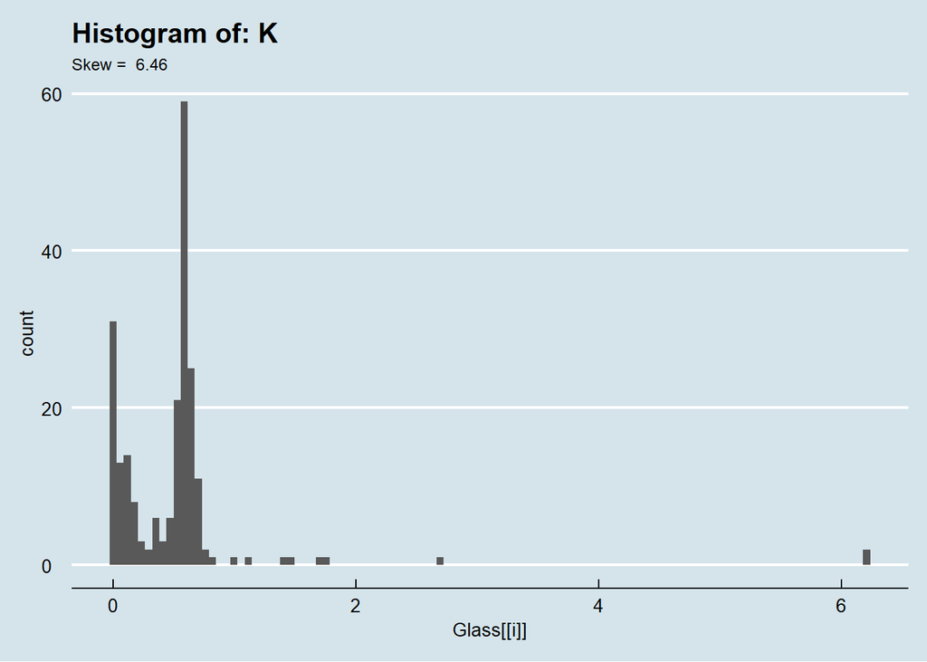

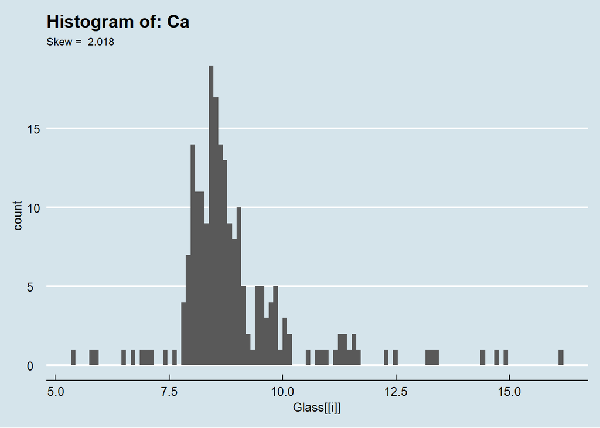

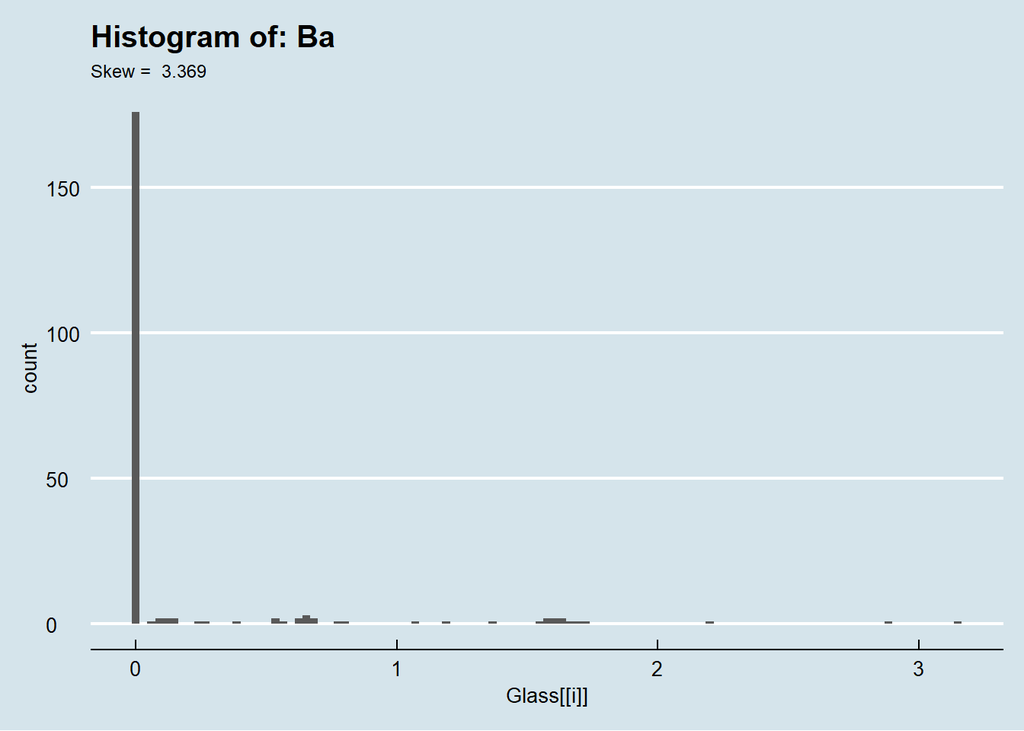

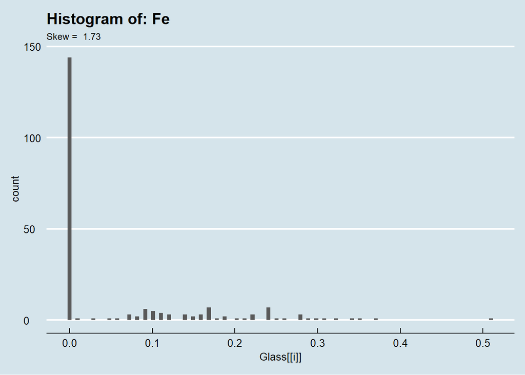

```r
colNames = colnames(Glass)

for( i in 1:9) {
  gg = ggplot(Glass, aes(x = Glass[[i]])) +
  geom_histogram(bins = trunc(length(Glass[[i]])/2)) +
  ggtitle(paste0("Histogram of: ", colNames[i]), sub = paste("Skew = ", round(skewness(Glass[[i]]) , 3) )) +
    theme_economist()
  print(gg)
}
```

`Mg` has a clear outlier in the lower end of the distribution. `Fe` and `Ba` are highly skewed. Log transformations of `Fe` and `Ba` improve the distributions.

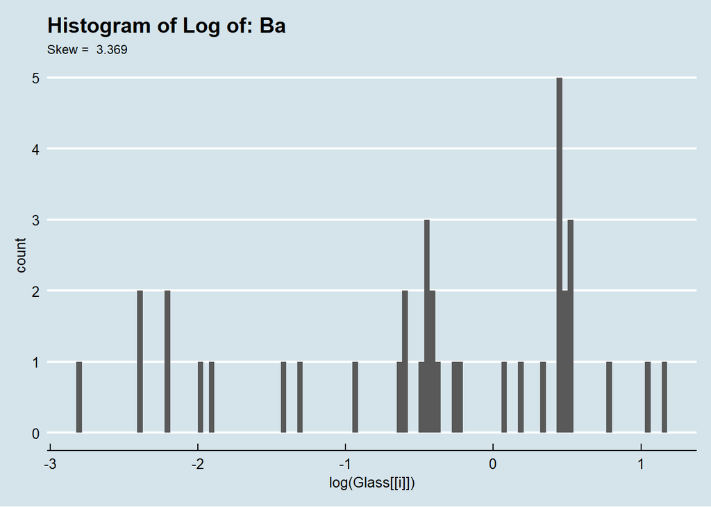

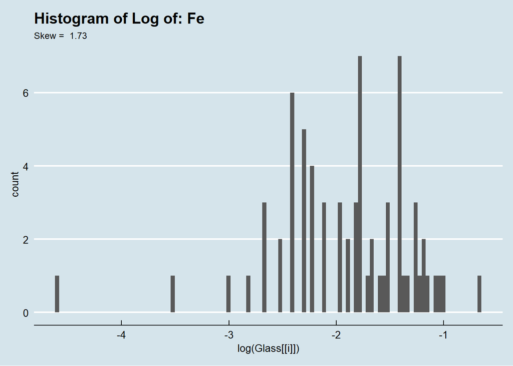

```r
for( i in 8:9) {
  gg = ggplot(Glass, aes(x = log(Glass[[i]]))) +
  geom_histogram(bins = trunc(length(Glass[[i]])/2)) +
  ggtitle(paste0("Histogram of Log of: ", colNames[i]), sub = paste("Skew = ", round(skewness(Glass[[i]]) , 3) )) +
    theme_economist()
  print(gg)
}
```

- Do there appear to be any outliers in the data? Are any predictors skewed?
- Are there any relevant transformations of one or more predictors that might improve the classification model?